# Table of Contents

**Si no compartes el conocimeinto no sirve para nada.** [Michio Kaku](https://www.youtube.com/watch?v=6rDxlolYUQw)

- [Referencia bibliográfica para los ejercicios](https://www.alfonsogonzalez.es/asignaturas/3_eso/ejercicios_3_eso_propuestos.php)
- Referencia bibliográfica para la teoria: Texto de SM y referenciasque se citan a páginas de Internet.

# Polinomios

## Expresiones algebraicas

Una **expresión algebraica** es una expresión matemática en la que intervienen letras, números y los signos de operaciones aritméticas.

Las letras reciben el nombre de variables o indeterminadas y representan números o cantidades desconocidas.

ejemplo: A(x)=2x²−3x+12

## Valor numérico de una expresión algebraica

El valor numérico de una expresión algebraica es el resultado obtenido al sustituir cada una de las variables por números.

## Monomios

Un **monomio** es una expresión algebraica formada por el producto de un número real por una o varias variables elevadas a exponentes naturales.

Los monomios constan de dos partes:

- **Parte literal:** formada por las variables y sus exponentes correspondientes.
- **Coeficiente:** o parte numérica, es el número que multiplica a la parte literal.

El **grado de un monomio** es la suma de todos los exponentes de las variables que intervienen en la parte literal.

1.1 Indica el coeficiente, parte literal y grado de estos monomios.

a) -3x³y²z⁴

b) -5b²c³

c) $x^{15}y$

d) $ - \frac{2}{3} x y⁵$

1.2 Determina si los monomios son semejantes o no.

a) $\frac{1}{2}x²y³z⁵ \quad y \quad -5z⁵x²y³$

b) 6x³y⁴ y 6x⁴y³

c) xy³ y -xy³

d) 7x y -x

1.3 Escribe el monomio opuesto de estos monomios.

a) $\frac{1}{2}xy³z²$

b) -4a²b³

c) -5x⁹

d) $9x^{11}$

1.4 Escribe, si se puede, un monomio:

a) coeficiente 2 y parte literal xy⁶.

b) coeficiente −3 y semejante a −2x³.

c) De grado 7 y semejante a -4x²y

d) parte literal x³y⁴ y opuesto a −4x³y.

### Suma y diferencia de monomios

Para sumar o restar monomios semejantes se suman o restan sus coeficientes y se escribe la misma parte literal que tienen ambos.

Ejemplo

Calcula la suma y la diferencia de $A(x) = 2x^2 $ y $B(x) = −x^2$.

$A(x) + B(x) = 2x^2 − x^2 = (2 − 1)x^2 = x^2$

$A(x) − B(x) = 2x^2 − (−x^2) = (2 + 1)x^2 = 3x^2$

Calcula la suma y resta de A(x) = −3x y B(x) = 4x².

A(x) + B(x) = −3x + 4x² A(x) − B(x) = −3x − 4x²

### Producto de un número por un monomio

Para multiplicar un número real por un monomio se multiplica el número por el coeficiente del monomio y se escribe la misma parte literal.

Ejemplos

```
2 ⋅ 3x^2 = 6x^2

−3⋅5x^2y=−15x^2y
```

### Producto de monomios

Para multiplicar cualquier par de monomios, se multiplican los coeficientes y las partes literales.

Ejemplo

### Potencia de un monomio

Para calcular la potencia de un monomio se eleva al exponente el coeficiente y cada una de las variables de la parte literal.

Ejemplo

Calcula [A(x, y)]³ siendo el monomio A(x, y) = −3x²y³.

$[A(x, y)]³ = (−3x²y³)³ = (−3)³ ⋅ (x²)³ ⋅ (y³)³ = −27 ⋅ x^{2 \cdot 3} ⋅ y^{3 \cdot 3} = −27x^6y^9$

1.5 Realiza las operaciones

a) 6x² + 2x² − x² + 3x² − x²

b) 3x²y² − 2x²y² + 6²y² − x²2y²

c) (−5ab) ⋅ (6abc)

d) (−8x²y) ⋅ (−4xy² ) e) (15xy) : (−3x) f) (2xyz) : (−2xy)

1.6 Simplifica las siguientes expresiones.

a) −2x³ − x² + 5x² − 6x + x − 2x² − 6x

b) 5x − (x² + 3x³ ) + 3x² − x³ + 2x

c) 11x⁷y³ + 4xy⁵ − 9x⁷y³ + xy⁵ − x²

1.7 Calcula: − x²y − (−3x² ⋅ 7y) + (16x²y³z : 4y²z).

1.8 Determina el grado, las variables y el término independiente de estos polinomios.

a) P (x, y) = −2x⁵ − x²y² + 5x³ − 1 + 3x³ + 3

b) Q (x, y) = x² + 4x³ − x − 9 + 4x⁴y³

c) R (x, y) = x⁹ − x⁷y³ + y¹3 − 4

d) S (x, y, z) = 7x²yz − 3xy²z + 8xyz²

1.9 Reduce este polinomio y calcula su opuesto.

R (x) = x⁵ + 1 − 3 + 4x⁵ − 3x − 2x

```python
1.10
```

[output not shown]

```python
1.11
```

```
1.11
```

## Polinomios. Operaciones con polinomios

Un polinomio es una expresión algebraica formada por la suma de varios monomios no semejantes, que se llaman términos.

- El término principal es el monomio de mayor grado. Su coeficiente es el coeficiente principal.
- El término independiente es el monomio que no tiene parte literal.
- Se llama grado del polinomio al mayor de los grados de los monomios que lo forman.

### Suma y diferencia de polinomios

Para sumar o restar polinomios se suman o restan los monomios semejantes que los forman.

Ejemplo

Si P(x) = −3x² + 5x − 2 y Q(x) = 5x³ − x² − 3, calcula:

- P(x) + Q(x) = −3x² + 5x − 2 + 5x³ − x² − 3 = 5x³ − 4x² + 5x − 5
- P(x) − Q(x) = (−3x² + 5x − 2) − (5x³ − x² − 3) = −3x² + 5x − 2 − 5x³ + x² + 3 =

  ```
                   = −5x³ − 2x² + 5x + 1
  ```

### Producto de un número por un polinomio

Para multiplicar un número real por un polinomio, se multiplica dicho número por cada uno de los monomios que forman el polinomio.

Ejemplo

Dado el polinomio P(x, y) = 3x⁴ − 5xy, calcula:

- 2P(x, y) = 2(3x⁴ − 5xy) = 6x⁴ − 10xy
- $− \frac{3}{5}P(x,y)=− \frac{3}{5}(3x⁴−5xy)=− \frac{9}{5}x⁴+3xy$

Ten en cuenta

El producto también se puede escribir en la forma habitual de una multiplicación.

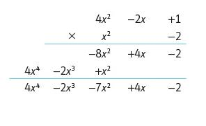

```python
from IPython.display import Image
Image("/media/enri/Mi_Proyecto/Apoyo-3-ESO/Matemáticas 3º ESO/figuras/multiplicar_polinomios.jpg")
```

### Extracción de un factor común

Si los monomios de un polinomio tienen factores comunes, se puede expresar el polinomio como el producto de un monomio llamado factor común por otro polinomio de grado menor. Esta operación se llama extracción de factor común.

Ejemplo

Extrae factor común en el polinomio 3x⁴y² − 6x²y + 12x³y².

El factor común es 3x²y, por tanto: 3x⁴y²−6x²y+12x³y²=3x²y(x²y−2+4xy)

1.11 Calcula el valor numérico del polinomio en cada caso.

a) P (x) = 3x⁶ + 2x⁵ − 3x⁴ - x² + 7x -2 para x = 0

b) P (x, y) = − x⁴y − x²y + 7xy − 2, para x = 1, y = 2.

1.12 Dados los polinomios:

P (x, y) = 3x²y + xy − 7x + y − 2

Q (x, y) = − xy² + 4y² − 3x

halla los valores numéricos:

P (0, 0) P (1, 1) Q (0, −1) Q (0, 2)

```python
1.13 Reduce los siguientes polinomios y calcula su valor numérico para x = 2.

a) P (x) = 4 − 3x² + x − x² + 1

b) Q (x) = x⁴ − 4 − 3x² + x − x² + 1 − 3x⁴ − 3x
```

[output not shown]

```python
1.14 Un número es raíz de un polinomio cuando el valor numérico del polinomio
para dicho número es cero. Determina si los números −4 y 4 son raíces
de este polinomio.

P (x) = x² − 5x + 4

¿Sabrías hallar otra raíz del polinomio?
```

[output not shown]

```python
1.15 Halla la suma, resta y producto de cada par de polinomios.

a) R (x) = x⁴ − x + 1; S (x) = x² + 1

b) R (x) = x + 1; S (x) = x² + x − 1

c) R (x) = 5x⁷ − x⁸ + 1; S (x) = x² + x⁶ − 1

d) R (x) = x⁵ − x⁴ + x³ + 2x + 1; S (x) = x³ + 2x

e) R (x) = 7x³ + 2x² + x − 3; S (x) = x⁴ + x² − 8

f) R (x) = x⁷ + 3; S (x) = x³ + x² + 4x + 2
```

[output not shown]

1.16 Calcula − A(x) + B(x)y − A(x) − B(x) con los polinomios:

A(x) = 3x⁴ − 5x³ + x² − 7

B(x) = −3x⁴ + x³ − 2x + 1

1.17 Calcula el producto de los dos polinomios del ejercicio anterior, utilizandola propiedad distributiva.

1.18 Calcula

a) (x 3 − 3x² + 2x) : x

b) (2x³ − 3x² − 5x − 5) : (x − 2)

c) (2x³ − 3x² + 4x − 3) : (x² + x − 1)

d) (x⁴ + x³ − x² + x + 1) : (x³ − 5)

e) (−6x⁵ + x³ + 2x + 2) : (4x³ + 2x + 3)

f) (x⁸ − 1) : (x⁵ + x³ + x + 2)

g) (x − 1) : x

h) (x² − 1) : (x + 1)

i) (x² − 5x + 6) : (x − 2)

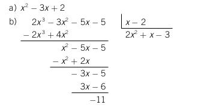

```python
from IPython.display import Image
Image("/media/enri/Mi_Proyecto/Apoyo-3-ESO/Matemáticas 3º ESO/figuras/division_polinomios.jpg")
```

1.19 Haz las siguientes divisiones y comprueba que están bien realizadas.

a) (x³ − 4x² + 5x − 2) : (x² − 2)

b) (x⁴ + x² + 3) : (x³ + 3x² + 2x + 6)

1.20

1.21 Saca factor común en los siguientes polinomios.

a) 8x² − 4x

b) 18x³ y² − 12x²y³

c) 30a²b − 15ab² + 5a²b²

d) −12ab³ + 4b² − 6b⁴

e) 34a⁴ − 14a³b + 28ab³

f) 20a⁴b²c + 36a²b − 18a³b²

1.22 Saca factor común en estos polinomios.

b) x ⋅ (xy²− y) + y² ⋅ (4xy − 3y)

c) \frac{x² - 2x}{7} - \frac{x² - x}{5}

1.23

## Identidades notables

### Cuadrado de una suma

El cuadrado de una suma de dos términos es igual al cuadrado del primer término más el cuadrado del segundo término más el doble producto de los dos términos.

$$(a+b)²=a²+b²+2ab$$

Ejemplo

Opera y simplifica la siguiente expresión.

(2x+3x²)2=(2x)²+(3x²)2+2⋅2x⋅3x²=4x²+9x⁴+12x³=9x⁴+12x³+4x²

### Cuadrado de una diferencia

El cuadrado de una diferencia de dos términos es igual al cuadrado del primer término más el cuadrado del segundo término menos el doble producto de los dos términos.

$$(a−b)²=a²+b²−2ab$$

Ejemplo

Desarrolla la siguiente identidad notable.

$(\frac{1}{2}x−x²)²=(\frac{1}{2}x)² + (x²)² − 2 \cdot \frac{1}{2}x \cdot x² = \frac{1}{4} x² +x⁴ − x³ = x⁴ − x³+ \frac{1}{4}x²$

### Suma por diferencia

El producto de la suma de dos términos por su diferencia es igual al cuadrado del primer término menos el cuadrado del segundo término.

(a+b)(a−b) = a²−b²

Ejemplo

Calcula y simplifica.

$(\frac{2}{3} x + \frac{1}{2} x²)(\frac{2}{3} x − \frac{1}{2} x²) = (\frac{2}{3} x)² − (\frac{1}{2} x²)² = \frac{4}{9} x² − \frac{1}{4} x⁴ = − \frac{1}{4}x⁴ + \frac{4}{9}x²$

1.24 Desarrolla los siguientes cuadrados

a) (x+7)²

b) (2a+1)²

c) (6+x)²

d) (3a²+2b)²

e) (x-4)²

f) (3a-b)²

g) (5-x)²

h) (2b²-5b³)²

1.25 Desarrolla

a) (3x³-a²)2

b) (x²+x³)2

c) (2x+x³)²

d) (6ab²-2y)2

1.26 Expresa como cuadrado de una suma o una diferencia, según convenga.

a) x² + 6x + 9

b) 4x² − 12xy + 9y²

c) x² + 4xy + 4y²

d) x⁴ + 2x² + 1

1.27 Calcula los siguientes productos.

a) (x + 7) ⋅ (x − 7)

b) (7x + 4y) ⋅ (7x − 4y)

1.28 Estudia si estas expresiones se pueden expresar como suma por diferencia.

a) x² − 1

b) x⁴ − 9

a) (x + 1) ⋅ (x − 1)

c) 16 − x²

1.29 Expresa en forma de producto.

a) 4x² − 4x + 1

b) 9a²2 − 30ab + 25b²

c) 100x² − 4z⁶

1.30

1.31 Simplifica las fracciones algebraicas.

a) $\quad \frac{x³}{xy} $

a) $\quad \frac{5x³y²}{3xy} $

a) $\quad \frac{6x²y}{3x²y²} $

a) $\quad \frac{4x²y}{4xy} $

1.32 Simplifica

a) $\quad \frac{x²-4x+4}{x-2} $

a) $\quad \frac{x²-9}{2x-6} $

1.33 Calcular **a**, para que a) $\quad \frac{x²-4ax+a²}{2x+3} = 2x+3$

1.34 Indica si las siguientes expresiones son o no monomios.

a) 2x² + yz

c) 5x⁵y²

e) $\quad \frac{3}{2}x + \frac{1}{3}y$

f) 3ab + 2a²

1.35 Di si los monomios son semejantes.

a) xz, 3xy, −6xy

b) ab, a²b, 7b

c) 4c⁹d, c⁷d, cd⁴

d) 8xy² , 7xy

1.36 Realiza estas sumas de monomios.

a) xz + 3xz + 6xz

b) a²b + 9a²b + 27a²b

c) 9c⁹ + c⁹ + c⁹

d) 8xy + 7xy + 43xy + 23xy

1.37 Efectúa las siguientes restas de monomios.

a) 3xz − 6xz

b) 9a*2b − 2a²b

c) 18xy − 7xy − 3xy − 3xy

d) 5x⁹9 − x⁹ − x⁹ − x⁹

1.39 Realiza las operaciones e indica el grado del monomio resultante.

a) 2x² + 3x² − 7x² + 8x² − x²

b) 5xy³ − 2xy³ + 7xy³ − 3xy³ + 12xy³

c) 3abc − 2abc + 6abc + 9abc − 4ab

d) 5xz − 3xz + 15xz − 11xz + 8xz − 3xz

e) (2xyz) ⋅ (2x²yz³ )

f) (−2abc) ⋅ (3a²b²c²) ⋅ (− bc)

g) 7x ⋅ (2xy) ⋅ (−3xy 5 ) ⋅ (xy)

h) (6ac³ ) ⋅ (−2a²c³ ) ⋅ (−3ac) ⋅ (−4a³c² )

i) (21x²y³ ) : (7xy² )

j) (9abc) : (3bc)

k) (16x⁴y⁵a³b⁶) : (8x²y³a²b⁵ )

l) (5m³n²g⁴ ) : (2mng)

1.39 Haz las siguientes operaciones.

a) − xz + 6xz + xyz − 8xz

b) 9a²b − 2a²b + 8a²b − a²b

c) 9c⁹ − c⁹ − c⁹ + 10c⁹

d) 8xy + 7xy − xy + 3xy − xy

a) − xz + 6xz + xyz − 8xz

b) 9a²b − 2a²b + 8a²b − a²b

c) 9c⁹ − c⁹ − c⁹ + 10c⁹

d) 8xy + 7xy − xy + 3xy − xy

1.41 Efectúa las siguientes divisiones de monomios.

a) 9xy : 3xy

b) 9ab : ab

c) 15x⁸ : 5x⁸

d) 8xy² : 2xy²

e) 15x⁹ : 3x⁹

f) 32x⁷ : 8x⁴

1.42 Calcula y simplifica el resultado todo lo que puedas.

a) 2x² − 5(− x² ) + 8x² − (2x) ⋅ (3x)

b) 2x ⋅ (− y) + 7xy − yx + (−4x) ⋅ (−5y)

c) 3x² − (− x)² + 3(− x² ) + (−3) ⋅ (− x)²

d) (2xy − 3xy + 7xy) ⋅ (2ab)

e) (x² − 3x² + 6x² − 2x² ) ⋅ (−5zx)

1.43

1.44 Indica el grado, el término independiente y el polinomio opuesto de los polinomios.

a) P (x) = − x³ + x² − 7x − 2

b) Q (x) = − x² + 2x + 6

c) R (x) = x + 1

d) S (x) = 8

e) T (x) = 12x − x² + x⁴

f) $ \quadU ( x ) = \frac{1}{2} x² - x- \frac{1}{6}$

11.46 Reduce los siguientes polinomios.

a) P (x) = − x² − x − 2 − x³ + x 2 − x − 2

b) Q (x) = − x² + x² + 6 − x + x² − 7x − 2

c) R (x) = x + 1 − x + x²

d) S (x) = 8 − x + 34 − x + 324

e) T (x) = x⁴ + x⁴ − x³ + x²2 − 7x − 2

f) $\quad \frac{1}{2}x² - x - \frac{1}{6} - \frac{2}{7}x²$

11.47 Calcula el valor numérico de cada polinomio para los valores de la variable.

a) A (x) = x + 1, para x = 1

b) B (x) = x⁴ + 3, para x = 2

c) C (x) = 4x⁵ − x²2 + 3, para x = −1

d) D (x) = −9x⁴ + 7x² + 5, para x = 1

e) E (x) = x³ + x² + x + 2, para x = −2

f) F (x) = x⁴ + x⁴ − x³ + x² − 7x − 2, para x = 0

g) G (x) = −14, para x = −2

1.48 Halla los valores numéricos para el polinomio:

P (x, y) = 2x 2 y + xy 2 − 3xy + 5x − 6y + 9

a) P (0, 0)

b) P (1, 1)

c) P (−1, 1)

d) P (1, −1)

e) P (1, 2)

f) P (2, 1)

¿CÓMO SE CALCULA EL COEFICIENTE DE UN POLINOMIO CONOCIENDO UNO DE SUS VALORES NUMÉRICOS ?

Calcula el valor de k en el polinomio P(x) = x² − x + k, si P(2) = 5.

PRIMERO . Se sustituye, en el polinomio, la variable por su valor.

P ( 2 ) = 2² − 2 + k = 5

SEGUNDO . Se despeja k en la ecuación resultante.

4-2+k = 5

k = 5-4+2 = 3

1.50 Calcula el valor de k en cada polinomio, sabiendo que P(1) = 6.

a) P (x) = kx⁷ + x³ + 3x + 1

b) P (x) = kx + kx + 4

c) P (x) = 9x⁵ + kx² + kx − k

d) P (x)= kx⁶ − kx³ + kx + k

e) P (x) = k

1.51 Dados los polinomios:

P (x) = 2x⁵ − 3x⁴ + 7x³ − 2x² + 3x − 6

Q (x) = 3x⁴ − 2x³ + 5x² − 7x − 1

R (x) = 3x² − x + 1

S (x) = 2x + 3

calcula.

a) P (x) + Q (x)

b) Q (x) + P (x)

c) P (x) − S (x)

d) Q (x) − P (x)

e) P (x) + R (x)

f) R (x) + S (x)

g) Q (x) − R (x)

h) R (x) − P (x)

1.52 Suma y resta los siguientes polinomios.

a) P (x) = −7x + 4; Q (x) = 2x + 5

b) P (x) = −3x² + 1; Q (x) = − x² + 2x

c) P (x) = −3x² + 1; Q (x) = − x² + 2x + 6

d) P (x) = −5x³ + x² − 7x − 2; Q (x) = 5x³ + x² + 4x − 2

e) $\quad \frac{1}{2}x² - 2xy - \frac{3}{2} y² \; ; \; Q(x) = x²-xy-y²$

f) $P (x) = \frac{1}{2}x² −2xy − \frac{3}{2}y² ; Q (x) = \frac{1}{33}x² − 2xy − \frac{2}{3}y²$

g) $P (x) = x² - \frac{1}{2}x -3; Q (x) = − \frac{1}{2}x² + \frac{1}{3}x − 1$

h) $P (x) = x² − 5x − 3; Q (x) = − \frac{1}{2}x² + \frac{1}{3}$

1.53 Dados los polinomios:

P (x) = 2x 5 − 3x 4 + 7x 3 − 2x 2 + 3x − 6

Q (x) = 3x − 2x + 5x − 7x − 1

R (x) = 3x 2 − x + 1

S (x) = 2x + 3

calcula.

a) P (x) + Q (x) + R (x) + S (x) c) [P (x) + Q (x)] − [R (x) + Q (x)] b) P (x) − R (x) + S (x) − Q (x) d) [P (x) − Q (x)] − [R (x) − Q (x)]

1.54 Halla cuál es el polinomio Q (x) que hay que sumar a P (x) = x 2 + 2x − 1 para obtener como resultado R (x).

a) R (x) = x − 1

b) R (x) = 2x² − x − 6

c) R (x) = 5x² − x + 1

d) R (x) = −7x² − 3x

e) R (x) = x³ − x

f) R (x) = x³ − x²

1.55 Dados los polinomios:

P (x) = 2x⁶ − 7x⁴ + 2x³ − 2x² + x − 1

Q (x) = 3x⁵ − 2x³ + x² − x − 1

R (x) = x² − x + 1

calcula.

a) P (x) ⋅ Q (x) b) Q (x) ⋅ R (x) c) P (x) ⋅ R (x) d) R (x) ⋅ R (x)

1.56 Dados los polinomios:

P (x) = 2x⁵ − 3x⁴ + 7x³ − 2x² + 3x − 6

Q (x) = 3x⁴ − 2x³ + 5x² − 7x − 1

R (x) = 3x² − x + 1

S (x) = 2x + 3

calcula.

a) [P (x) − Q (x)] ⋅ S (x)

b) [R (x) − Q (x)] ⋅ S(x)

c) [P (x) + Q (x) + R (x)] ⋅ S (x) 1.57 Realiza las siguientes operaciones d) [P (x) + Q (x) − R (x)] ⋅ S (x)

1.57 Realiza las siguientes operaciones

a) $\quad \left ( \frac{1}{2}x² + \frac{3}{4}x \right ) - \left (\frac{5}{4}x +7 \right ) + \left ( \frac{7}{2}x²- \frac{9}{4}x+3 \right )$

b) $\quad \left ( \frac{5}{3}x³ - \frac{2}{5}x²+x-7 \right ) \cdot \left ( \frac{5}{2}x²-3x \right )$

c) $\quad \frac{2}{5}x² \cdot (x³-3x²+x-1)-x³ \cdot \left ( \frac{1}{2}x² - x + \frac{2}{3}\right ) $

d) $\quad \frac{5}{6}x \cdot (x⁵-x²+3x-1)-x⁵ \cdot \left ( \frac{1}{3}x² - \frac{5}{2}x + \frac{4}{3} \right ) $

1.58 División

a) (4x⁴ + 3x³ − 5x² + x + 7) : (x − 1)

b) (4x⁴ − 2x³ + 3x² − 2x + 5) : (x + 1)

c) (7x⁵ + 4x⁴ + 3x³ − 5x² + 2x − 1) : (x² + x)

d) (x⁴ − 2x³ + x² − x + 3) : (x² + x + 1)

e) (4x⁴ − 2x³ + 7x² − 2x + 3) : (x² − x − 2)

1.59 Desarrolla.

a) (3x + 2)²

b) (3x − 2)²

c) (3x 2 − 2x)²

d) (7x 3 + 4x 2 )²

e) (2x + 7) ⋅ (2x − 7)

f) (2x² + 3x) ⋅ (2x² − 3x)

g) (x⁴ + 3x⁵ ) ⋅ (x⁴ − 3x⁵ )

h) $\quad (2x - \frac{1}{2})²$

1.60 Desarrolla estos cuadrados.

a) (x + 5)²

b) (2y − 7)²

c) (− y − 8)²

d) (xy − 6x)²

e) (− x − y)²

f) (x + 2xy)²

1.61

Realiza la siguiente operación.

(2x − 3)² − (2 + x)²

Se desarrolla el polinomio aplicando los resultados de las igualdades notables.

(2x − 3)² − (2 + x)² = (4x² − 12x + 9) − (4 + 4x + x² )

PRIMERO. Se quitan los paréntesis, teniendo en cuenta los signos.

(4x² − 12x + 9) − (4 + 4x + x² ) = 4x² − 12x + 9 − 4 − 4x − x²

SEGUNDO. Se reduce el polinomio.

4x² − 12x + 9 − 4 − 4x − x² = 3x² − 16x + 5

Por tanto: (2x − 3)² − (2 + x)² = 3x² − 16x + 5.

1.63 Desarrolla y simplifica las siguientes expresiones.

a) 5x² + (2x² + 1) 2 − 2x⁴ − (x − 1)²

b) (x − 1)² − (x² + x + 1)

c) (5x + 5) 2 − (5x − 5)²

d) (2x³ − 3x² )² − (2x + 2) ⋅ (2x − 2)

e) (x + 6)² − (x − 6)² − (x − 5) ⋅ (x + 5)

f) (2x + 1)² − (2x − 1)² + (2x + 1) ⋅ (3x + 2)

1.64 Expresa estos polinomios como el cuadrado de una suma o diferencia.

a) 9x² + 18x + 9

b) 16x² − 16x + 4

c) x²2 + 16x + 64

d) 4x² + 4x + 1

1.64 Expresa el área de cada figura mediante un polinomio. Simplifica su expresión.

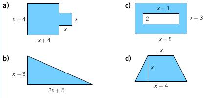

```python
from IPython.display import Image
Image("/media/enri/Mi_Proyecto/Apoyo-3-ESO/Matemáticas 3º ESO/figuras/polinomio_areafiguras.jpg")
```

1.66 Escribe los polinomios como producto de dos factores.

a) x² − 16

b) x⁴ − 36

c) 4x² − 25

d) x² − 4x + 4

e) 16x² − 24xy + 9y²

f) 16x² + 24x² + 9

1.67

1.68 Extrae factor común en estas expresiones.

a) 3x² − 4x

b) (x + 1) + 3(x + 1)

c) xy − 6xyz − 5xyzt

d) 3x − 4x² − 6x³

¿CÓMO SE SIMPLIFICAN FRACCIONES ALGEBRAICAS ?

Simplifica.

( y⁴ − y³ ) ⋅ ( x² − 2x + 1 )

xy² ( x − 1 )

PRIMERO .

Se descomponen el numerador y el denominador en tantos factores como sea posible.

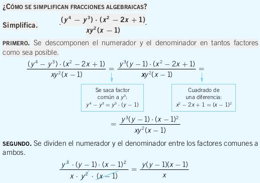

```python
from IPython.display import Image
Image("/media/enri/Mi_Proyecto/Apoyo-3-ESO/Matemáticas 3º ESO/figuras/simplificar_fracciones.jpg")
```

1.69 Simplifica estas expresiones aplicando las igualdades notables y extrayendo factor común.

a) 7x² − 14x + 7

b) 16x² + 64x + 64

c) x 3 − 2x² + x

d) 18x⁴ − 12x² + 2

e) (2x + 4) ⋅ (x − 2)

f) (x − 5) ⋅ (x² + 5x) 1.71 g) (− x − 7) ⋅ (x − 7)

h) (− x² + 5) ⋅ (− x² − 5)

1.71 Simplifica las fracciones algebraicas.

a) $\quad \frac{x² + 2x + 1}{x ( x + 1 )}$

b) $ \quad \frac{x² ( x² − 4 )}{x ( x − 2 )}$

c) $\quad \frac{y² ( x² − 4 x + 4 )}{x ( x − 2 )} $

d) $\quad \frac{( x² − 9 )( y² − 16 )}{xy ( 2x − 6 )( y + 4 ) 2}$

# 1.72 Simplifica las siguientes fracciones algebraicas

a) $\quad \frac{x³ ( x² − 16 )}{x ( x + 4 )} $

b) $\quad \frac{x ( 2x² − 16 x + 32 )}{( x² − 16 )} $

c) $\quad \frac{18 x⁴ − 36 x² + 18}{9 x² ( x − 1 )²} $

d) $\quad \frac{( 3 x − 2 )²}{9 x² − 4} $

e) $\quad \frac{( 6 x + 8 )²}{27 x² − 48} $

f) $\quad \frac{( 3 x + 12 )( x − 4 )}{2 x² − 32} $

1.73

1.74